# TFA exam - Guiding solution

Lars Relund Nielsen

# R - Assignment 1 (55%)

Consider the dataset in the file `bom.csv` containing a Bill of Materials (BOM) for a group of brewery products and materials. The dataset contains a row for each material and product, i.e. a row gives information about how much of the material is needed to produce the product. A product is produced in batches, and the BOM provides information about the quantities of the materials needed to produce one batch of each product.

The columns/variables are:

- `product_id`: Product id.
- `product_desc`: Product description.
- `product_type`: Product type.
- `product_group_id`: Product group id.
- `product_group_desc`: Product group description.
- `material_id`: Material id.
- `material_quantity`: Amount needed for producing a batch of the product.
- `material_unit`: Unit used for the material (kilogram (KG), meters (M), items (I)).
- `material_unit_price`: Unit price/cost in Euros.
- `material_valid_from`: First date the material is valid to use.
- `material_valid_to`: Last date the material is valid to use.

The dataset can be read using:

```r
library(tidyverse)
dat <- read_csv("bom.csv")
```

Use the *dplyr* package in *tidyverse* to calculate relevant summary tables (tibbles/data frames), and answer/complete the following questions/tasks:

## Question 1

How many different products, product groups and materials are considered in the dataset?

```r
# load packages
library(tidyverse)
library(skimr)
res <- dat |>
   skim() |>
   print()
```

```
## ── Data Summary ────────────────────────
##                            Values
## Name                       dat
## Number of rows             4550
## Number of columns          11
## _______________________
## Column type frequency:
##   character                7
##   Date                     2
##   numeric                  2
## ________________________
## Group variables            None
##
## ── Variable type: character ──────────────────────────────────────────────────────────────
##   skim_variable      n_missing complete_rate min max empty n_unique whitespace
## 1 product_id                 0             1   4   7     0      608          0
## 2 product_desc               0             1  11  40     0      608          0
## 3 product_type               0             1   3   6     0        3          0
## 4 product_group_id           0             1   3   5     0       35          0
## 5 product_group_desc         0             1   3  33     0       35          0
## 6 material_id                0             1   6   9     0      794          0
## 7 material_unit              0             1   1   2     0        2          0
##
## ── Variable type: Date ───────────────────────────────────────────────────────────────────
##   skim_variable       n_missing complete_rate min        max        median     n_unique
## 1 material_valid_from         0             1 2007-01-01 2024-03-30 2017-08-09      657
## 2 material_valid_to           0             1 2022-01-10 9999-12-31 9999-12-31       48
##
## ── Variable type: numeric ────────────────────────────────────────────────────────────────
##   skim_variable       n_missing complete_rate     mean       sd          p0    p25
## 1 material_quantity           0             1 6928.    10229.   -1000       7
## 2 material_unit_price         0             1    0.523     1.21     0.00151 0.0537
##        p50       p75     p100 hist
## 1 125      20000     24000    ▇▁▁▁▃
## 2   0.0963     0.153     9.69 ▇▁▁▁▁
```

There are 608 products in 35 product groups which use 794 different materials.

## Question 2

Find all materials that are valid on date January 1st 2022 (2022-01-01). Is the material with id `M34491` used?

```r
dt <- ymd("2022-01-01")
res1 <- dat |>
   filter(dt >= material_valid_from & dt <= material_valid_to) |>
   print()
```

```
## # A tibble: 3,792 × 11
##    product_id product_desc    product_type product_group_id product_group_desc material_id
##    <chr>      <chr>           <chr>        <chr>            <chr>              <chr>
##  1 P10239     LEFF BLON KEG … Keg          PG81             LEFFE              M15470
##  2 P10239     LEFF BLON KEG … Keg          PG81             LEFFE              M15611
##  3 P10239     LEFF BLON KEG … Keg          PG81             LEFFE              M50119857
##  4 P10239     LEFF BLON KEG … Keg          PG81             LEFFE              M50121478
##  5 P10351     LEFF RAD OW 4x… Bottle       PG81             LEFFE              M15665
##  6 P10351     LEFF RAD OW 4x… Bottle       PG81             LEFFE              M50113789
##  7 P10351     LEFF RAD OW 4x… Bottle       PG81             LEFFE              M50115526
##  8 P10351     LEFF RAD OW 4x… Bottle       PG81             LEFFE              M50119089
##  9 P10351     LEFF RAD OW 4x… Bottle       PG81             LEFFE              M50119474
## 10 P10351     LEFF RAD OW 4x… Bottle       PG81             LEFFE              M50119857
## # ℹ 3,782 more rows
## # ℹ 5 more variables: material_quantity <dbl>, material_unit <chr>,
## #   material_unit_price <dbl>, material_valid_from <date>, material_valid_to <date>
```

```r
res1 |> distinct(material_id)
```

```
## # A tibble: 713 × 1
##    material_id
##    <chr>
##  1 M15470
##  2 M15611
##  3 M50119857
##  4 M50121478
##  5 M15665
##  6 M50113789
##  7 M50115526
##  8 M50119089
##  9 M50119474
## 10 M50120181
## # ℹ 703 more rows
```

```r
(dat |> filter(material_id == "M34491") |> nrow()) > 0
```

```
## [1] FALSE
```

We filter out materials not holding the date. Material with id `M34491` is not used.

## Question 3

Create a function `get_valid` with the following features

- Takes a BOM dataset and a date as arguments.
- Removes all materials that are not valid any more at the date and returns the filtered dataset.

That is, do the same as in the previous question with an arbitrary date. Note: `get_valid` returns a data frame which can be used in a pipe. Test the function by running:

```r
get_valid(dat, "2023-02-15")
```

```r
get_valid <- function(dat, dt) {
   tmp <- dat |> filter(dt >= material_valid_from & dt <= material_valid_to)
   return(tmp)
}
get_valid(dat, ymd("2023-02-15"))
```

```
## # A tibble: 4,163 × 11
##    product_id product_desc    product_type product_group_id product_group_desc material_id
##    <chr>      <chr>           <chr>        <chr>            <chr>              <chr>
##  1 P100160    CRATE DOM 30CL… Bottle       PG98             NO BRAND (ONLY FO… M15657
##  2 P100160    CRATE DOM 30CL… Bottle       PG98             NO BRAND (ONLY FO… M63992
##  3 P10239     LEFF BLON KEG … Keg          PG81             LEFFE              M15470
##  4 P10239     LEFF BLON KEG … Keg          PG81             LEFFE              M15611
##  5 P10239     LEFF BLON KEG … Keg          PG81             LEFFE              M50119857
##  6 P10239     LEFF BLON KEG … Keg          PG81             LEFFE              M50121478
##  7 P10351     LEFF RAD OW 4x… Bottle       PG81             LEFFE              M15665
##  8 P10351     LEFF RAD OW 4x… Bottle       PG81             LEFFE              M50113789
##  9 P10351     LEFF RAD OW 4x… Bottle       PG81             LEFFE              M50115526
## 10 P10351     LEFF RAD OW 4x… Bottle       PG81             LEFFE              M50119089
## # ℹ 4,153 more rows
## # ℹ 5 more variables: material_quantity <dbl>, material_unit <chr>,
## #   material_unit_price <dbl>, material_valid_from <date>, material_valid_to <date>
```

Function `get_valid` return a data frame which can be used in the next questions.

## Question 4

How many rows have negative material quantity? Modify your data in the following way:

- If `material_quantity` is negative, then assume this is a typo and set the quantity to the positive number instead.
- Add a column `material_cost` equal to the material quantity times the material unit price.
- Remove all rows where material quantity is zero.

```r
res1 <- dat |>
   filter(material_quantity < 0) |>
   nrow() |>
   print()
```

```
## [1] 5
```

```r
res2 <- dat |>
   mutate(
      material_quantity = if_else(material_quantity < 0, -material_quantity, material_quantity),
      material_cost = material_quantity * material_unit_price
   ) |>
   filter(material_quantity != 0) |>
   print()
```

```
## # A tibble: 4,464 × 12
##    product_id product_desc    product_type product_group_id product_group_desc material_id
##    <chr>      <chr>           <chr>        <chr>            <chr>              <chr>
##  1 P100160    CRATE DOM 30CL… Bottle       PG98             NO BRAND (ONLY FO… M15657
##  2 P100160    CRATE DOM 30CL… Bottle       PG98             NO BRAND (ONLY FO… M63992
##  3 P100297    CORO FLAV OW 4… Bottle       PG35             CORONA             M15665
##  4 P100297    CORO FLAV OW 4… Bottle       PG35             CORONA             M51073841
##  5 P100297    CORO FLAV OW 4… Bottle       PG35             CORONA             M51130304
##  6 P100297    CORO FLAV OW 4… Bottle       PG35             CORONA             M51361448
##  7 P100297    CORO FLAV OW 4… Bottle       PG35             CORONA             M51375867
##  8 P100297    CORO FLAV OW 4… Bottle       PG35             CORONA             M51402730
##  9 P100297    CORO FLAV OW 4… Bottle       PG35             CORONA             M51419235
## 10 P100298    CORO FLAV OW 8… Bottle       PG35             CORONA             M15665
## # ℹ 4,454 more rows
## # ℹ 6 more variables: material_quantity <dbl>, material_unit <chr>,
## #   material_unit_price <dbl>, material_valid_from <date>, material_valid_to <date>,
## #   material_cost <dbl>
```

There are 5 rows with negative material quantity. The new dataset is stored in `res2`.

## Question 5

Consider the modified dataset from the previous question (if you did not succeed in modifying the data, then consider the data in the file `bom-modified.csv`).

For each product group, calculate/find the number of different products and materials. Moreover, for each product group, calculate the average number of different materials used per product. Hint: The function `n_distinct` can be used to find the number of different items within a group.

Which product group contains the most products, and which product group has the highest average number of different materials?

```r
dat <- res2  # set dat to cleaned data (result of previous question)
res <- dat %>%
   group_by(product_group_id, product_group_desc) %>%
   summarise(
      products = n_distinct(product_id),
      materials = n_distinct(material_id),
      avg_materials = materials/products
   ) |>
   arrange(desc(products)) |>
   print()
```

```
## # A tibble: 35 × 5
## # Groups:   product_group_id [35]
##    product_group_id product_group_desc products materials avg_materials
##    <chr>            <chr>                 <int>     <int>         <dbl>
##  1 PG81             LEFFE                   157       300         1.91
##  2 PG71             JUPILER                 134       109         0.813
##  3 PG130            STELLA ARTOIS            85       138         1.62
##  4 PG35             CORONA                   56        43         0.768
##  5 PG39             CUBANISTO                32        29         0.906
##  6 PG65             HOEGAARDEN               24        85         3.54
##  7 PG26             BUD                      21        48         2.29
##  8 PG15             BELLE VUE                18        39         2.17
##  9 PG64             HERTOG JAN               11        36         3.27
## 10 PG28             BUDWEISER                 9        31         3.44
## # ℹ 25 more rows
```

```r
res1 <- res |>
   arrange(desc(avg_materials)) |>
   print(n = 2)
```

```
## # A tibble: 35 × 5
## # Groups:   product_group_id [35]
##   product_group_id product_group_desc    products materials avg_materials
##   <chr>            <chr>                    <int>     <int>         <dbl>
## 1 PG118            ROYAL DUTCH POST HORN        1        10            10
## 2 PG74             KWAK                         1        10            10
## # ℹ 33 more rows
```

Product group PG81 (LEFFE) contains most products while e.g. group PG118 (ROYAL DUTCH POST HORN) has the highest average.

## Question 6

A dataset with material info is given in the file `materials.csv`.

The columns/variables are:

- `material_id`: Material id.
- `material_desc`: Material description.
- `material_group_id`: Material group id.
- `marterial_group_desc`: Material group description

The dataset can be read using:

```r
dat_mat <- read_csv("materials.csv")
```

Answer the following questions:

- How many different material groups are considered?
- Join the dataset with the BOM dataset. Which material group is used in most products?
- Consider material groups `MG2130201` and `MG2130202`. For each material group and product type, calculate the minimum, average and maximum quantity used.

```r
res1 <- dat_mat |>
   distinct(material_group_id) |>
   nrow() |>
   print()
```

```
## [1] 19
```

There are 19 different material groups.

```r
# Join datasets
dat <- dat %>%
   left_join(dat_mat)

res2 <- dat |>
   group_by(material_group_id, material_group_desc) |>
   summarise(products = n_distinct(product_id)) |>
   arrange(desc(products)) |>
   print(n = 3)
```

```
## # A tibble: 19 × 3
## # Groups:   material_group_id [19]
##   material_group_id material_group_desc products
##   <chr>             <chr>                  <int>
## 1 MG2140101         COLOR                    584
## 2 MG2130201         WOOD                     509
## 3 MG2050102         PRY-OFF                  331
## # ℹ 16 more rows
```

Material group MG2140101 (COLOR) are used in 584 products.

```r
id <- c("MG2130201", "MG2130202")
res3 <- dat |>
   filter(material_group_id %in% id) |>
   group_by(material_group_desc, product_type) |>
   summarise(min = min(material_quantity), avg = mean(material_quantity), max = max(material_quantity)) |>
   arrange(desc(material_group_desc)) |>
   print()
```

```
## # A tibble: 3 × 5
## # Groups:   material_group_desc [1]
##   material_group_desc product_type   min   avg   max
##   <chr>               <chr>        <dbl> <dbl> <dbl>
## 1 WOOD                Bottle           4  12.9    33
## 2 WOOD                Can              8 731.   1000
## 3 WOOD                Keg            125 125     125
```

The minimum, average and maximum quantity used given group and type is given in `res3`.

# R - Assignment 2 (45%)

Answer this assignment using the *ggplot2* package in *tidyverse* (you may need *dplyr* for preparing the datasets you want to plot). Work with the joined dataset from Assignment 1, which can be read using:

```r
library(tidyverse)
dat <- read_csv("bom-m-groups.csv")
```

The columns/variables are as in Assignment 1 plus the following columns:

- `material_cost`: The cost of using the material in the production of a batch of a product.
- `material_desc`: Material description.
- `material_group_id`: Material group id.
- `marterial_group_desc`: Material group description.

## Question 1

Create a visualization showing the variation in material costs with the following features:

- A histogram is used (with argument `binwidth = 100`).
- Fill colors are used to identify the product type.
- A plot is made for each product type (facet).
- Legends are added at the bottom of the plot.
- Informative figure title and axis titles are given.

In which interval does the material cost mostly lie? What product type has high material cost?

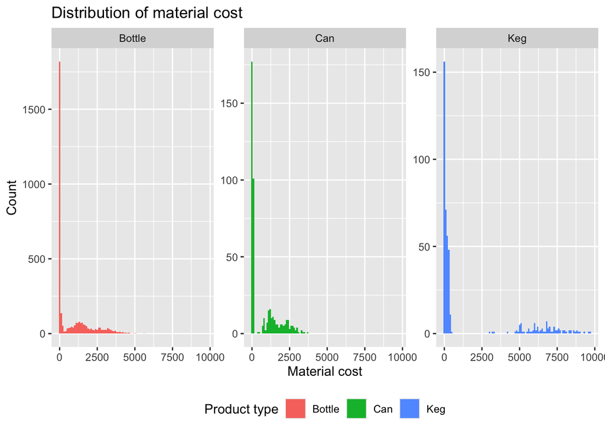

```r
dat |>
   ggplot(aes(x = material_cost, fill = product_type)) +
   geom_histogram(binwidth = 100) +
   facet_wrap(vars(product_type), scales = "free_y") +
   labs(title = "Distribution of material cost",
       x = "Material cost", y = "Count", fill = "Product type") +
   theme(legend.position = "bottom")
```

```r
dat |> filter(material_cost >= 5000) |> count(product_type)
```

```
## # A tibble: 2 × 2
##   product_type     n
##   <chr>        <int>
## 1 Bottle           5
## 2 Keg             86
```

Most material cost are in the interval 0-100. Batches of Kegs use materials with a high cost.

## Question 2

Create a visualization showing the number of products for each product type with the following features:

- Bars are used for each product type.
- Fill colors are used to identify the product type.
- Legends are added at the bottom of the plot.
- Informative figure title and axis titles are given.

Which product type contains most products?

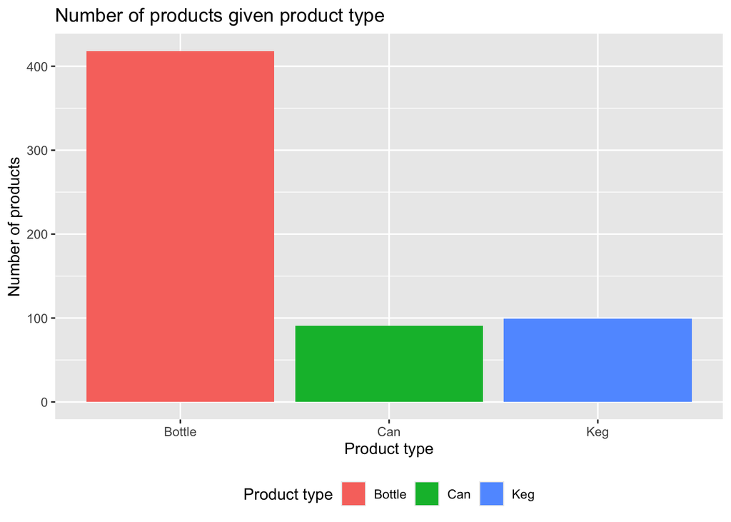

```r
dat |>
   group_by(product_type, product_id) |>
   summarise(products = n_distinct(product_id)) |>
   ungroup() |>
   ggplot(aes(x = product_type, y = products, fill = product_type)) +
   geom_col() +
   labs(title = "Number of products given product type",
       x = "Product type", y = "Number of products", fill = "Product type") +
   theme(legend.position = "bottom",
         # axis.text.x = element_text(angle = 90, vjust = 0.5, hjust=1)
   )
```

Product type Bottle contains most products.

## Question 3

Create a visualization showing the total costs of selected products with the following features:

- The total cost of a product is the sum of the material costs.
- Only 6 products for each product type are plotted. Pick the 6 with the highest total cost (most expensive).
- Bars are used for each product ordered such that the height of the bars decreases over the x-axis.
- Fill colors are used to identify the product type.
- Legends are added at the bottom of the plot.
- Informative figure title and axis titles are given.

What product type category has the lowest total costs among the products visualized?

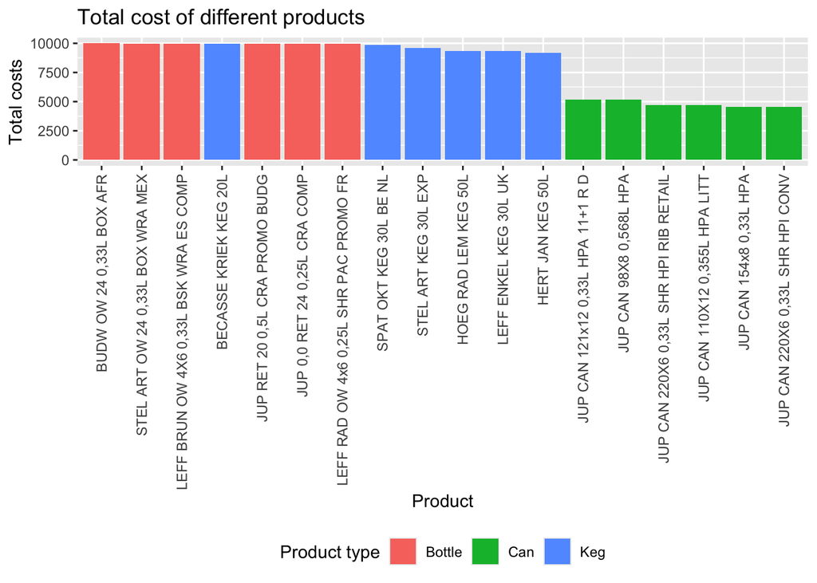

```r
dat |>
   group_by(product_id, product_desc, product_type) |>
   summarise(total_costs = sum(material_cost)) |>
   # arrange(desc(total_costs)) |>
   group_by(product_type) |>
   slice_max(total_costs, n = 6, with_ties = F) |>
   ungroup() |>
   ggplot(aes(x = reorder(product_desc, -total_costs), y = total_costs, fill = product_type)) +
   geom_col() +
   labs(title = "Total cost of different products",
       x = "Product", y = "Total costs", fill = "Product type") +
   theme(legend.position = "bottom",
         axis.text.x = element_text(angle = 90, vjust = 0.5, hjust=1)
   )
```

Product type Can have lowest total costs.

## Question 4

Create a visualization showing the proportion of material costs used in each material group given a product with the following features:

- Consider products with id `P10393`, `P64433` and `P100160`.
- Bars are used for each product such that the height is the same since we want to compare proportions (`position = "fill"`).
- Fill colors are used to identify the material group.
- Legends are added at the bottom of the plot.
- Informative figure title and axis titles are given.

Which material group has the highest relative cost in the product with id `P100160`.

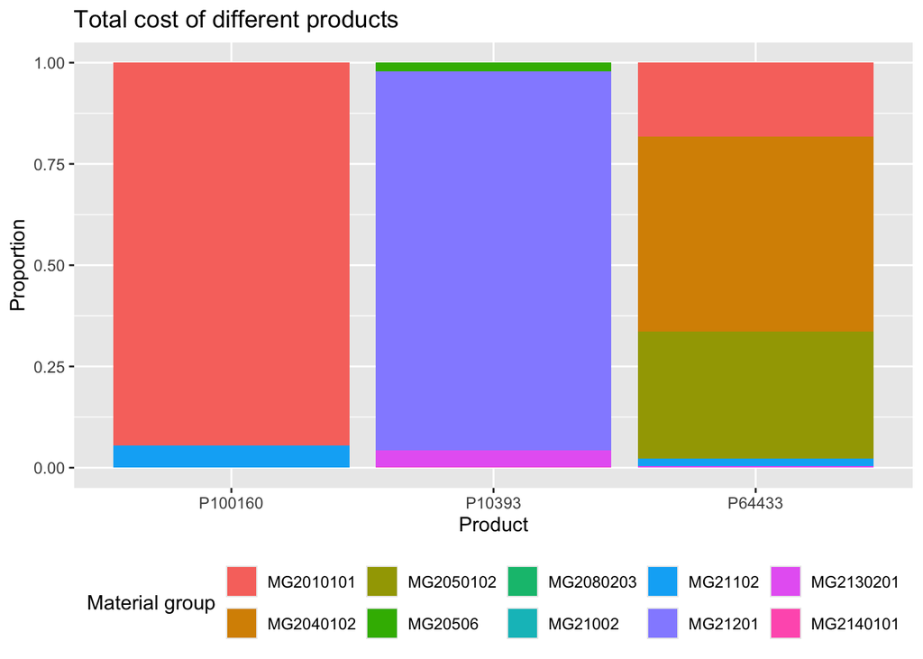

```r
products <- c("P10393", "P64433", "P100160")
dat %>%
   filter(product_id %in% products) |>
   ggplot(aes(x = product_id, y = material_cost, fill = material_group_id)) +
   geom_col(position = "fill") +
   labs(title = "Total cost of different products",
       x = "Product", y = "Proportion", fill = "Material group") +
   theme(legend.position = "bottom",
         # axis.text.x = element_text(angle = 90, vjust = 0.5, hjust=1)
   )
```

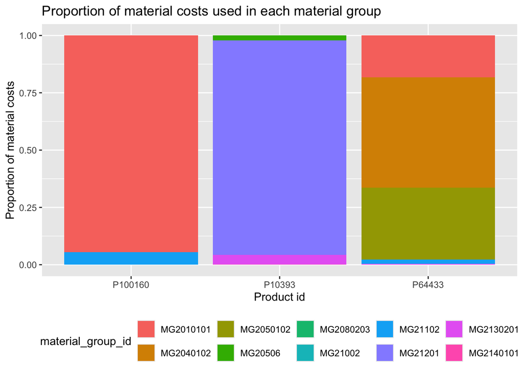

```r
dat %>% filter(product_id %in% c("P10393", "P64433", "P100160")) %>% # filtering the products
  group_by(material_group_id, product_id) %>% # grouping by material group id
  summarise(total_cost = sum(material_cost)) %>%
   group_by(product_id) |> # calculating the total cost of a material group
  mutate(relative_cost = total_cost/sum(total_cost)) %>%
   arrange(product_id) |> # calculating the relative cost of each material group

# Plotting the relative costs of each material group for each product:
ggplot(aes(x = product_id, y = relative_cost, fill = material_group_id)) + # setting the x-axis to product id, y-axis to relative cost and fill to material group id
  geom_bar(stat = "identity", position = "fill") + # creating a bar plot with position fill
  theme(legend.position = "bottom") + # setting the legend position to bottom
  ggtitle("Proportion of material costs used in each material group") + # Informative title of the plot
  xlab("Product id") + ylab("Proportion of material costs") # setting the x-axis and y-axis labels
```

```r
dat |> distinct(material_group_id, material_group_desc) |> filter(material_group_id == "MG2010101")
```

```
## # A tibble: 1 × 2
##   material_group_id material_group_desc
##   <chr>             <chr>
## 1 MG2010101         RETURNABLE BOTTLES
```

Product `P100160` has highest relative cost in material group `MG2010101` (Returnable bottels).

## Question 5

Create a visualization showing the variation in material costs given the product type with the following features:

- Only consider the material group with id `MG2130201`.
- Variation is visualized using a density.
- Fill colors are used to identify the product type.
- Legends are added at the bottom of the plot.
- Informative figure title and axis titles are given.

Which product type has the highest mean value in this product group?

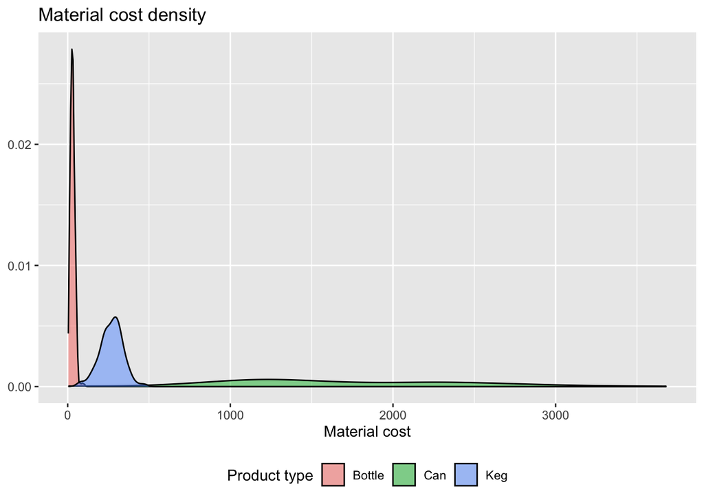

```r
dat |>
   filter(material_group_id == "MG2130201") |>
   ggplot(aes(x = material_cost, fill = product_type)) +
   geom_density(alpha = 0.5) +
   labs(title = "Material cost density",
       x = "Material cost", y = NULL, fill = "Product type") +
   theme(legend.position = "bottom",
         # axis.text.x = element_text(angle = 90, vjust = 0.5, hjust=1)
   )
```

Product type Can have the highest mean since its peak is at the highest value.